# PA_9.1

Author

Mehrpad Moattari

Published

December 1, 2023

```python
import pandas as pd
from sklearn.pipeline import Pipeline
from sklearn.preprocessing import OneHotEncoder
from sklearn.compose import ColumnTransformer
from sklearn.metrics import mean_squared_error
from sklearn.model_selection import train_test_split
from sklearn.linear_model import LinearRegression, LogisticRegression
from sklearn.metrics import r2_score
from sklearn.metrics import mean_squared_error
from sklearn.neighbors import KNeighborsRegressor
from sklearn.tree import DecisionTreeRegressor
from sklearn.preprocessing import StandardScaler, OneHotEncoder, PolynomialFeatures, FunctionTransformer
from sklearn.metrics import precision_score, recall_score, f1_score
from sklearn.discriminant_analysis import LinearDiscriminantAnalysis
from sklearn.svm import SVC
```

## The Data

At this link, you will find a dataset containing information about heart disease patients: https://www.dropbox.com/scl/fi/0vrpdnq5asmeulc4gd50y/ha_1.csv?rlkey=ciisalceotl77ffqhqe3kujzv&dl=1

A description of the original dataset can be found here: https://archive.ics.uci.edu/dataset/45/heart+disease (However, this dataset has been cleaned and reduced, and the people have been given fictious names.)

```python
import pandas as pd
heart = pd.read_csv("https://www.dropbox.com/scl/fi/0vrpdnq5asmeulc4gd50y/ha_1.csv?rlkey=ciisalceotl77ffqhqe3kujzv&dl=1")
heart.head()
```

|  | Name | age | sex | cp | trtbps | chol | restecg | thalach | diagnosis |
| --- | --- | --- | --- | --- | --- | --- | --- | --- | --- |
| 0 | Magnolia Cassin | 60 | 1 | 1 | 117 | 230 | 1 | 160 | No Disease |
| 1 | Dr. Cathern Heathcote | 60 | 0 | 3 | 102 | 318 | 1 | 160 | Disease |
| 2 | Miles Wolf | 62 | 0 | 3 | 130 | 263 | 1 | 97 | No Disease |
| 3 | Mikaila Block | 43 | 1 | 1 | 115 | 303 | 1 | 181 | Disease |
| 4 | Mrs. Jacquline Marquardt | 66 | 1 | 1 | 120 | 302 | 0 | 151 | Disease |

## 1. Logistic Regression

Fit a Logistic Regression using only `age` and `chol` (cholesterol) as predictors.

For a 55 year old, how high would their cholesterol need to be for the doctors to predict heart disease is present?

How high for the doctors to estimate a 90% chance that heart disease is present?

```python
X = heart[["age", 'chol']]
y = heart['diagnosis']
```

```python
logfit = LogisticRegression().fit(X,y)
logfit.coef_
```

```
array([[0.04686331, 0.00180124]])
```

```python
logfit.intercept_
```

```
array([-3.24011226])
```

0 = .047 * 55 + .0018 * x - 3.24

x = 363.9

```python
import math
math.log(.9/(1-.9))
```

```
2.1972245773362196
```

2.19 = .047 * 55 + .0018 * x - 3.24

x = 1580.56

## 2. Linear Discriminant Analysis

Fit an LDA model using only `age` and `chol` (cholesterol) as predictors.

For a 55 year old, how high would their cholesterol need to be for the doctors to predict heart disease is present?

```python
ldafit = LinearDiscriminantAnalysis().fit(X,y)
ldafit.coef_
```

```
array([[0.04655744, 0.00178967]])
```

```python
ldafit.intercept_
```

```
array([-3.21967766])
```

0 = .46655 + .0018x - 3.22

x = 368.2

## 3. Support Vector Classifier

Fit an SVC model using only `age` and `chol` as predictors. Don’t forget to tune the regularization parameter.

For a 55 year old, how high would their cholesterol need to be for the doctors to predict heart disease is present?

```python
from sklearn.model_selection import GridSearchCV
svc = Pipeline([("svc", SVC(kernel = 'linear'))])
tune = {'svc__C': [.1,.2,.3,.4,5,.6,.7,.7,.8,.9,1,2,3,4,5,6,7,8,9,10]}

gscv1 = GridSearchCV(svc, tune, cv = 5, scoring='r2')
gscv1fit = gscv1.fit(X,y)
```

[output not shown]

[output cut: 3148 more lines]

[output not shown]

```python
gscv1fit.best_params_
```

```
{'svc__C': 0.1}
```

```python
svc = Pipeline([("svc", SVC(C = .1, kernel = 'linear'))])
svcfit = svc.fit(X,y)

svcfit.named_steps['svc'].coef_
```

```
array([[0.06439804, 0.00366067]])
```

```python
svcfit.named_steps['svc'].intercept_
```

```
array([-4.68655043])
```

0 = .064 * 55 + .0037 * x - 4.69

x = 316.22

## 4. Comparing Decision Boundaries

Make a scatterplot of `age` and `chol`, coloring the points by their true disease outcome. Add a line to the plot representing the **linear separator** (aka **decision boundary**) for each of the three models above.

```python
svcfit.named_steps['svc'].coef_[0]
```

```
array([0.06439804, 0.00366067])
```

x2 = -w1/w2 * X1 - b/w2

```python
ldafit.coef_
```

```
array([[0.04655744, 0.00178967]])
```

```python
logfit.coef_
```

```
array([[0.04686331, 0.00180124]])
```

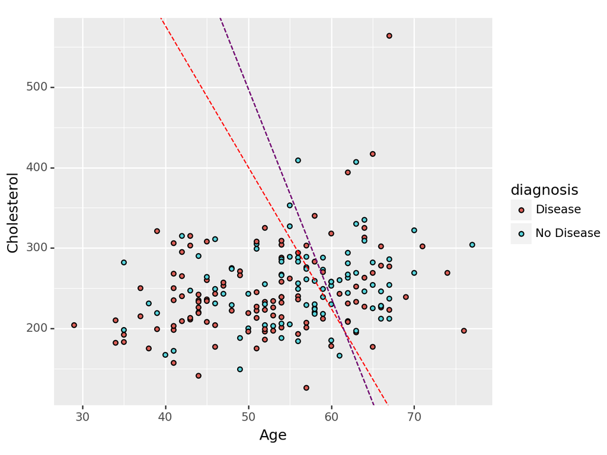

```
<Figure Size: (640 x 480)>
```

```python
from plotnine import *
(ggplot(heart, aes(x = 'age', y = 'chol', fill = 'diagnosis')) +
geom_point() +
geom_abline(intercept=-svcfit.named_steps['svc'].intercept_/svcfit.named_steps['svc'].coef_[0][1], slope=-svcfit.named_steps['svc'].coef_[0][0]/svcfit.named_steps['svc'].coef_[0][1], color='red', linetype='dashed') +
geom_abline(intercept=-logfit.intercept_/logfit.coef_[0][1], slope=-logfit.coef_[0][0]/logfit.coef_[0][1], color='black', linetype='dashed') +
geom_abline(intercept=-ldafit.intercept_/ldafit.coef_[0][1], slope=-ldafit.coef_[0][0]/ldafit.coef_[0][1], color='purple', linetype='dashed') +

 xlab("Age") +
ylab("Cholesterol"))
```